# Predictive Analytics of Perfect and Imperfect Dumbell Exercises

Gideon Obeisun

October 29, 2017

## Loading and Preprocessing the Datasets.

### The datasets for the project were loaded into R dataframes for further data analysis .A visual observation of the datasets provided for this project with Excel, reveals some NA values in some of the variable columns and some columns seem to be unrelated to the other columns such as,“user_name”,“raw_time”,and “new_window” which were filtered out of the dataframes.

```r
library(caret)
library(rpart)
library(randomForest)
library(ggplot2)


setwd("C:/Users/Gideon87/Documents/R/Coursera Practical Machine Learning Course")

pml_Training_Dataset<-read.csv("pml-training.csv",na.strings=c("NA",""))


pml_NonNA_Dataset<-pml_Training_Dataset[,colSums(is.na(pml_Training_Dataset)) == 0]

# Partioning the pml_Training_Dataset.

set.seed(32344)

pmlTraining_Index<-createDataPartition(y=pml_NonNA_Dataset$classe,p=0.7,list=FALSE)

pmlCleaner_TrainingData<-pml_NonNA_Dataset[pmlTraining_Index,]

pmlCleaner_TrainingData<-pml_NonNA_Dataset[,-c(1:7)]

pmlCleaner_TestingData<-pml_NonNA_Dataset[-pmlTraining_Index,]


pmlCleaner_TestingData<-pml_NonNA_Dataset[,-c(1:7)]
```

### Graphical trends can be seen between the accelerometric measurements and the Dumbell-bicep curls performed by the participants.

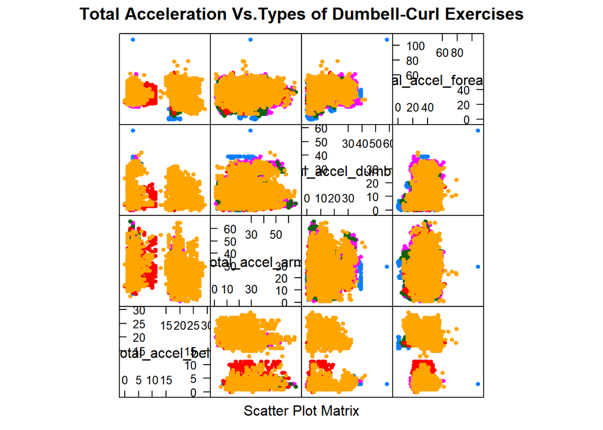

```r
Total_Values<-which(grepl("^total",colnames(pmlCleaner_TrainingData),ignore.case = F))

Total_Acceleration_Values<-pmlCleaner_TrainingData[,Total_Values]

featurePlot(x=Total_Acceleration_Values,y=pmlCleaner_TrainingData$classe,main="Total Acceleration Vs.Types of Dumbell-Curl Exercises",plot="pairs",pch=20)
```

## Model Fitting.

### The Recursive Partitioning and Random Forest Predictive alogrithm will be used to increase the reliability of the prediction accuracy the “classe” outcome based on the competitive benchmarked performances of the two algorithms.

```r
pmlTraining_Control<-trainControl(method="cv",number=6,allowParallel =TRUE)

ModFit<-train(classe~.,data=pmlCleaner_TrainingData,method="rpart",trControl=pmlTraining_Control)

ModFit
```

```
## CART
##
## 19622 samples
##    52 predictor
##     5 classes: 'A', 'B', 'C', 'D', 'E'
##
## No pre-processing
## Resampling: Cross-Validated (6 fold)
## Summary of sample sizes: 16353, 16350, 16352, 16352, 16352, 16351, ...
## Resampling results across tuning parameters:
##
##   cp          Accuracy   Kappa
##   0.03567868  0.5027022  0.35038939
##   0.05998671  0.4283455  0.22940539
##   0.11515454  0.3239262  0.06023722
##
## Accuracy was used to select the optimal model using  the largest value.
## The final value used for the model was cp = 0.03567868.
```

```r
# Using the Random Forest predictive model Algorithm.

RF_ModFit<-randomForest(classe~.,data=pmlCleaner_TrainingData,method="class")

RF_ModFit
```

```
##
## Call:
##  randomForest(formula = classe ~ ., data = pmlCleaner_TrainingData,      method = "class")
##                Type of random forest: classification
##                      Number of trees: 500
## No. of variables tried at each split: 7
##
##         OOB estimate of  error rate: 0.27%
## Confusion matrix:
##      A    B    C    D    E  class.error
## A 5577    2    0    0    1 0.0005376344
## B    9 3785    3    0    0 0.0031603898
## C    0   11 3411    0    0 0.0032144944
## D    0    0   19 3196    1 0.0062189055
## E    0    0    1    5 3601 0.0016634322
```

```r
RPart_PredictedValues<-predict(ModFit,pmlCleaner_TestingData)

confusionMatrix(pmlCleaner_TestingData$classe, RPart_PredictedValues)
```

```
## Confusion Matrix and Statistics
##
##           Reference
## Prediction    A    B    C    D    E
##          A 5080   81  405    0   14
##          B 1581 1286  930    0    0
##          C 1587  108 1727    0    0
##          D 1449  568 1199    0    0
##          E  524  486  966    0 1631
##
## Overall Statistics
##
##                Accuracy : 0.4956
##                  95% CI : (0.4885, 0.5026)
##     No Information Rate : 0.5209
##     P-Value [Acc > NIR] : 1
##
##                   Kappa : 0.3407
##  Mcnemar's Test P-Value : NA
##
## Statistics by Class:
##
##                      Class: A Class: B Class: C Class: D Class: E
## Sensitivity            0.4970  0.50850  0.33040       NA  0.99149
## Specificity            0.9468  0.85310  0.88225   0.8361  0.89008
## Pos Pred Value         0.9104  0.33869  0.50468       NA  0.45218
## Neg Pred Value         0.6339  0.92145  0.78395       NA  0.99913
## Prevalence             0.5209  0.12889  0.26638   0.0000  0.08383
## Detection Rate         0.2589  0.06554  0.08801   0.0000  0.08312
## Detection Prevalence   0.2844  0.19351  0.17440   0.1639  0.18382
## Balanced Accuracy      0.7219  0.68080  0.60633       NA  0.94079
```

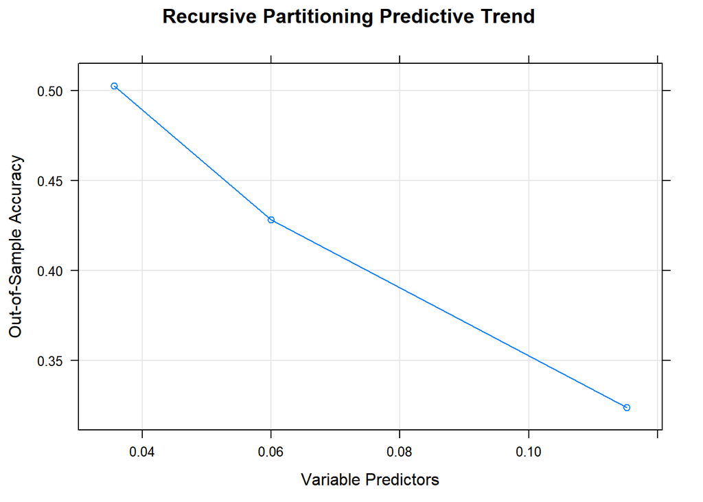

```r
plot(ModFit,log="y",xlab="Variable Predictors",ylab="Out-of-Sample Accuracy",
     main="Recursive Partitioning Predictive Trend ")
```

```r
RF_PredictedValues<-predict(RF_ModFit,pmlCleaner_TestingData,type="class")

confusionMatrix(pmlCleaner_TestingData$classe, RF_PredictedValues)
```

```
## Confusion Matrix and Statistics
##
##           Reference
## Prediction    A    B    C    D    E
##          A 5580    0    0    0    0
##          B    0 3797    0    0    0
##          C    0    0 3422    0    0
##          D    0    0    0 3216    0
##          E    0    0    0    0 3607
##
## Overall Statistics
##
##                Accuracy : 1
##                  95% CI : (0.9998, 1)
##     No Information Rate : 0.2844
##     P-Value [Acc > NIR] : < 2.2e-16
##
##                   Kappa : 1
##  Mcnemar's Test P-Value : NA
##
## Statistics by Class:
##
##                      Class: A Class: B Class: C Class: D Class: E
## Sensitivity            1.0000   1.0000   1.0000   1.0000   1.0000
## Specificity            1.0000   1.0000   1.0000   1.0000   1.0000
## Pos Pred Value         1.0000   1.0000   1.0000   1.0000   1.0000
## Neg Pred Value         1.0000   1.0000   1.0000   1.0000   1.0000
## Prevalence             0.2844   0.1935   0.1744   0.1639   0.1838
## Detection Rate         0.2844   0.1935   0.1744   0.1639   0.1838
## Detection Prevalence   0.2844   0.1935   0.1744   0.1639   0.1838
## Balanced Accuracy      1.0000   1.0000   1.0000   1.0000   1.0000
```

## Model Visualization

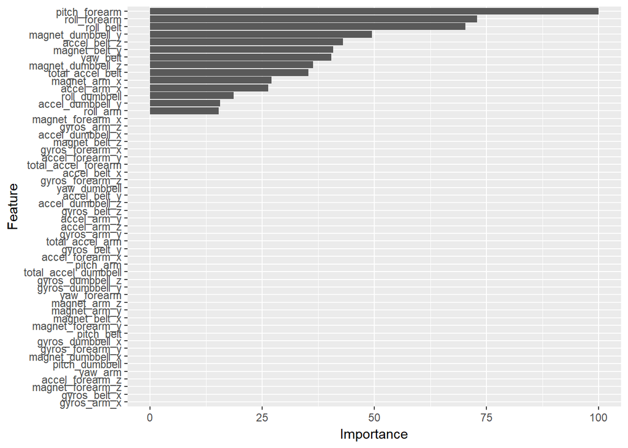

```r
ggplot(varImp(ModFit),aes(y=importance))+geom_bar(stat="identity")
```

## Predictive Model Testing.

```r
pmlTesting_Dataset<-read.csv("pml-testing.csv",na.strings=c("NA",""))

pmlTesting_Dataset2<-pmlTesting_Dataset[,colSums(is.na(pmlTesting_Dataset)) == 0]

pmlTesting_Dataset2<-pmlTesting_Dataset2[,-c(1:7)]

TwentyCases_Prediction <- predict(RF_ModFit,pmlTesting_Dataset2)

TwentyCases_Prediction
```

```
##  1  2  3  4  5  6  7  8  9 10 11 12 13 14 15 16 17 18 19 20
##  B  A  B  A  A  E  D  B  A  A  B  C  B  A  E  E  A  B  B  B
## Levels: A B C D E
```

```r
OutofSampleError<-1-(sum(RF_PredictedValues==pmlCleaner_TestingData$classe)/length(RF_PredictedValues))

OutofSample_Percentage<-OutofSampleError*100

paste0("Out of Sample Error is:",round(OutofSample_Percentage,digit=2),"%")
```

```
## [1] "Out of Sample Error is:0%"
```